# Risk Factor Analysis

## Outcome Variable

**Outcome Variable:** whz

## Predictor Variables

**Intervention Variable:** predexfd6

**Adjustment Set:**

- arm
- sex
- brthmon
- W_mage
- meducyrs
- feducyrs
- hhwealth_quart
- hfoodsec
- W_mhtcm
- W_mwtkg
- W_mbmi
- vagbrth
- W_gagebrth
- W_birthwt
- W_birthlen
- W_nrooms
- W_nchldlt5
- month
- W_parity
- impfloor
- impsan
- safeh20
- delta_W_mage
- delta_meducyrs
- delta_feducyrs
- delta_hhwealth_quart
- delta_hfoodsec
- delta_W_mhtcm
- delta_W_mwtkg
- delta_W_mbmi
- delta_vagbrth
- delta_W_gagebrth
- delta_W_birthwt
- delta_W_birthlen
- delta_W_nrooms
- delta_W_nchldlt5
- delta_month
- delta_W_parity
- delta_impfloor
- delta_impsan
- delta_safeh20

## Stratifying Variables

The analysis was stratified on these variable(s):

- agecat
- studyid
- country

## Data Summary

| agecat | studyid | country | predexfd6 | n_cell | n | outcome_variable |
| --- | --- | --- | --- | --- | --- | --- |
| Birth | CMC-V-BCS-2002 | INDIA | 1 | 7 | 7 | whz |
| Birth | CMC-V-BCS-2002 | INDIA | 0 | 0 | 7 | whz |
| Birth | EE | PAKISTAN | 1 | 24 | 28 | whz |
| Birth | EE | PAKISTAN | 0 | 4 | 28 | whz |
| Birth | GMS-Nepal | NEPAL | 1 | 390 | 522 | whz |
| Birth | GMS-Nepal | NEPAL | 0 | 132 | 522 | whz |
| Birth | IRC | INDIA | 1 | 0 | 12 | whz |
| Birth | IRC | INDIA | 0 | 12 | 12 | whz |
| Birth | JiVitA-3 | BANGLADESH | 1 | 8392 | 10744 | whz |
| Birth | JiVitA-3 | BANGLADESH | 0 | 2352 | 10744 | whz |
| Birth | JiVitA-4 | BANGLADESH | 1 | 1802 | 2224 | whz |
| Birth | JiVitA-4 | BANGLADESH | 0 | 422 | 2224 | whz |
| Birth | Keneba | GAMBIA | 1 | 450 | 1327 | whz |
| Birth | Keneba | GAMBIA | 0 | 877 | 1327 | whz |
| Birth | MAL-ED | BANGLADESH | 1 | 68 | 194 | whz |
| Birth | MAL-ED | BANGLADESH | 0 | 126 | 194 | whz |
| Birth | MAL-ED | BRAZIL | 1 | 5 | 57 | whz |
| Birth | MAL-ED | BRAZIL | 0 | 52 | 57 | whz |
| Birth | MAL-ED | INDIA | 1 | 4 | 37 | whz |
| Birth | MAL-ED | INDIA | 0 | 33 | 37 | whz |
| Birth | MAL-ED | NEPAL | 1 | 3 | 23 | whz |
| Birth | MAL-ED | NEPAL | 0 | 20 | 23 | whz |
| Birth | MAL-ED | PERU | 1 | 72 | 208 | whz |
| Birth | MAL-ED | PERU | 0 | 136 | 208 | whz |
| Birth | MAL-ED | SOUTH AFRICA | 1 | 1 | 90 | whz |
| Birth | MAL-ED | SOUTH AFRICA | 0 | 89 | 90 | whz |
| Birth | MAL-ED | TANZANIA, UNITED REPUBLIC OF | 1 | 0 | 105 | whz |
| Birth | MAL-ED | TANZANIA, UNITED REPUBLIC OF | 0 | 105 | 105 | whz |
| Birth | PROVIDE | BANGLADESH | 1 | 155 | 532 | whz |
| Birth | PROVIDE | BANGLADESH | 0 | 377 | 532 | whz |

[output cut: 70 more lines]

The following strata were considered:

- agecat: 24 months, studyid: CMC-V-BCS-2002, country: INDIA
- agecat: 24 months, studyid: EE, country: PAKISTAN
- agecat: 24 months, studyid: GMS-Nepal, country: NEPAL
- agecat: 24 months, studyid: IRC, country: INDIA
- agecat: 24 months, studyid: JiVitA-3, country: BANGLADESH
- agecat: 24 months, studyid: JiVitA-4, country: BANGLADESH
- agecat: 24 months, studyid: Keneba, country: GAMBIA
- agecat: 24 months, studyid: LCNI-5, country: MALAWI
- agecat: 24 months, studyid: MAL-ED, country: BANGLADESH
- agecat: 24 months, studyid: MAL-ED, country: BRAZIL
- agecat: 24 months, studyid: MAL-ED, country: INDIA
- agecat: 24 months, studyid: MAL-ED, country: NEPAL
- agecat: 24 months, studyid: MAL-ED, country: PERU
- agecat: 24 months, studyid: MAL-ED, country: SOUTH AFRICA
- agecat: 24 months, studyid: MAL-ED, country: TANZANIA, UNITED REPUBLIC OF
- agecat: 24 months, studyid: PROVIDE, country: BANGLADESH
- agecat: 6 months, studyid: CMC-V-BCS-2002, country: INDIA
- agecat: 6 months, studyid: EE, country: PAKISTAN
- agecat: 6 months, studyid: GMS-Nepal, country: NEPAL
- agecat: 6 months, studyid: IRC, country: INDIA
- agecat: 6 months, studyid: JiVitA-3, country: BANGLADESH
- agecat: 6 months, studyid: JiVitA-4, country: BANGLADESH
- agecat: 6 months, studyid: Keneba, country: GAMBIA
- agecat: 6 months, studyid: LCNI-5, country: MALAWI
- agecat: 6 months, studyid: MAL-ED, country: BANGLADESH
- agecat: 6 months, studyid: MAL-ED, country: BRAZIL
- agecat: 6 months, studyid: MAL-ED, country: INDIA
- agecat: 6 months, studyid: MAL-ED, country: NEPAL
- agecat: 6 months, studyid: MAL-ED, country: PERU
- agecat: 6 months, studyid: MAL-ED, country: SOUTH AFRICA
- agecat: 6 months, studyid: MAL-ED, country: TANZANIA, UNITED REPUBLIC OF
- agecat: 6 months, studyid: PROVIDE, country: BANGLADESH
- agecat: 6 months, studyid: SAS-CompFeed, country: INDIA
- agecat: 6 months, studyid: SAS-FoodSuppl, country: INDIA
- agecat: Birth, studyid: CMC-V-BCS-2002, country: INDIA
- agecat: Birth, studyid: EE, country: PAKISTAN
- agecat: Birth, studyid: GMS-Nepal, country: NEPAL
- agecat: Birth, studyid: IRC, country: INDIA
- agecat: Birth, studyid: JiVitA-3, country: BANGLADESH
- agecat: Birth, studyid: JiVitA-4, country: BANGLADESH
- agecat: Birth, studyid: Keneba, country: GAMBIA
- agecat: Birth, studyid: MAL-ED, country: BANGLADESH
- agecat: Birth, studyid: MAL-ED, country: BRAZIL
- agecat: Birth, studyid: MAL-ED, country: INDIA
- agecat: Birth, studyid: MAL-ED, country: NEPAL
- agecat: Birth, studyid: MAL-ED, country: PERU
- agecat: Birth, studyid: MAL-ED, country: SOUTH AFRICA
- agecat: Birth, studyid: MAL-ED, country: TANZANIA, UNITED REPUBLIC OF
- agecat: Birth, studyid: PROVIDE, country: BANGLADESH
- agecat: Birth, studyid: SAS-CompFeed, country: INDIA

### Dropped Strata

Some strata were dropped due to rare outcomes:

- agecat: Birth, studyid: CMC-V-BCS-2002, country: INDIA
- agecat: Birth, studyid: EE, country: PAKISTAN
- agecat: Birth, studyid: IRC, country: INDIA
- agecat: Birth, studyid: MAL-ED, country: INDIA
- agecat: Birth, studyid: MAL-ED, country: NEPAL
- agecat: Birth, studyid: MAL-ED, country: SOUTH AFRICA
- agecat: Birth, studyid: MAL-ED, country: TANZANIA, UNITED REPUBLIC OF
- agecat: 6 months, studyid: CMC-V-BCS-2002, country: INDIA
- agecat: 6 months, studyid: IRC, country: INDIA
- agecat: 6 months, studyid: MAL-ED, country: SOUTH AFRICA
- agecat: 6 months, studyid: MAL-ED, country: TANZANIA, UNITED REPUBLIC OF
- agecat: 6 months, studyid: SAS-FoodSuppl, country: INDIA
- agecat: 24 months, studyid: CMC-V-BCS-2002, country: INDIA
- agecat: 24 months, studyid: EE, country: PAKISTAN
- agecat: 24 months, studyid: IRC, country: INDIA
- agecat: 24 months, studyid: MAL-ED, country: SOUTH AFRICA
- agecat: 24 months, studyid: MAL-ED, country: TANZANIA, UNITED REPUBLIC OF

## Methods Detail

We’re interested in the causal parameters $E[Y_a]$ for all values of $a \in \mathcal{A}$. These parameters represent the mean outcome if, possibly contrary to fact, we intervened to set all units to have $A=a$. Under the randomization and positivity assumptions, these are identified by the statistical parameters $\psi_a=E_W[E_{Y|A,W}(Y|A=a,W)]$. In addition, we’re interested in the mean of $Y$, $E[Y]$ under no intervention (the observed mean). We will estimate these parameters by using SuperLearner to fit the relevant likelihood factors – $E_{Y|A,W}(Y|A=a,W)$ and $p(A=a|W)$, and then updating our likelihood fit using a joint TMLE.

For unadjusted analyses ($W=\{\}$), initial likelihoods were estimated using Lrnr_glm to estimate the simple $E(Y|A)$ and Lrnr_mean to estimate $p(A)$. For adjusted analyses, a small library containing Lrnr_glmnet, Lrnr_xgboost, and Lrnr_mean was used.

Having estimated these parameters, we will then use the delta method to estimate relative risks and attributable risks relative to a prespecified baseline level of $A$.

# Results Detail

## Results Plots

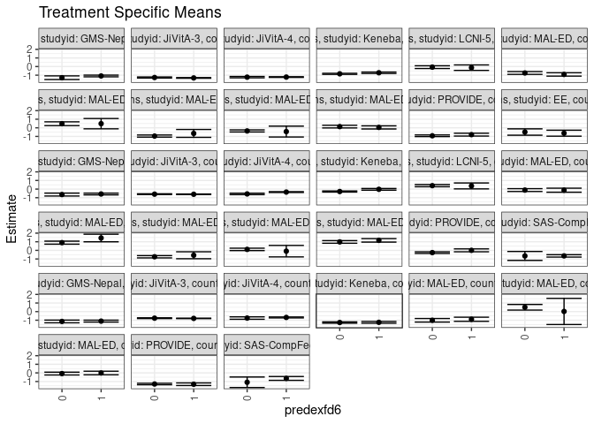

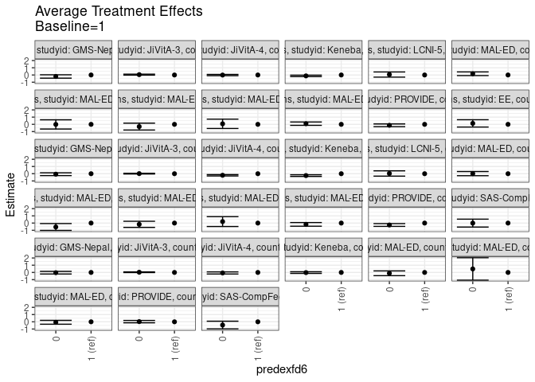

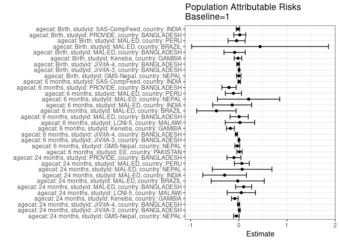

## Results Table

### Parameter: TSM

| agecat | studyid | country | intervention_level | baseline_level | estimate | ci_lower | ci_upper |
| --- | --- | --- | --- | --- | --- | --- | --- |
| Birth | GMS-Nepal | NEPAL | 1 | NA | -1.1054103 | -1.2175038 | -0.9933167 |
| Birth | GMS-Nepal | NEPAL | 0 | NA | -1.1416653 | -1.2987414 | -0.9845893 |
| Birth | JiVitA-3 | BANGLADESH | 1 | NA | -0.7869328 | -0.8117627 | -0.7621028 |
| Birth | JiVitA-3 | BANGLADESH | 0 | NA | -0.7596830 | -0.8036286 | -0.7157374 |
| Birth | JiVitA-4 | BANGLADESH | 1 | NA | -0.6762213 | -0.7310342 | -0.6214083 |
| Birth | JiVitA-4 | BANGLADESH | 0 | NA | -0.7475035 | -0.8887273 | -0.6062797 |
| Birth | Keneba | GAMBIA | 1 | NA | -1.2445312 | -1.3454126 | -1.1436498 |
| Birth | Keneba | GAMBIA | 0 | NA | -1.2661764 | -1.3428832 | -1.1894696 |
| Birth | MAL-ED | BANGLADESH | 1 | NA | -0.8890271 | -1.1281976 | -0.6498566 |
| Birth | MAL-ED | BANGLADESH | 0 | NA | -1.0058785 | -1.2132159 | -0.7985411 |
| Birth | MAL-ED | BRAZIL | 1 | NA | 0.0220000 | -1.4978207 | 1.5418207 |
| Birth | MAL-ED | BRAZIL | 0 | NA | 0.5069231 | 0.1803892 | 0.8334570 |
| Birth | MAL-ED | PERU | 1 | NA | -0.0130769 | -0.2240129 | 0.1978591 |
| Birth | MAL-ED | PERU | 0 | NA | -0.0799653 | -0.2430386 | 0.0831081 |
| Birth | PROVIDE | BANGLADESH | 1 | NA | -1.3191337 | -1.4698066 | -1.1684609 |
| Birth | PROVIDE | BANGLADESH | 0 | NA | -1.2931215 | -1.3795854 | -1.2066577 |
| Birth | SAS-CompFeed | INDIA | 1 | NA | -0.6419787 | -0.8661092 | -0.4178481 |
| Birth | SAS-CompFeed | INDIA | 0 | NA | -1.0901281 | -1.7027393 | -0.4775170 |
| 6 months | EE | PAKISTAN | 1 | NA | -0.6248062 | -0.9715960 | -0.2780164 |
| 6 months | EE | PAKISTAN | 0 | NA | -0.4893333 | -0.8590751 | -0.1195916 |
| 6 months | GMS-Nepal | NEPAL | 1 | NA | -0.5705311 | -0.6723254 | -0.4687368 |
| 6 months | GMS-Nepal | NEPAL | 0 | NA | -0.6351953 | -0.8040320 | -0.4663586 |
| 6 months | JiVitA-3 | BANGLADESH | 1 | NA | -0.6029649 | -0.6300968 | -0.5758331 |
| 6 months | JiVitA-3 | BANGLADESH | 0 | NA | -0.5890347 | -0.6346054 | -0.5434640 |
| 6 months | JiVitA-4 | BANGLADESH | 1 | NA | -0.3473740 | -0.3921352 | -0.3026128 |
| 6 months | JiVitA-4 | BANGLADESH | 0 | NA | -0.5623985 | -0.6440755 | -0.4807214 |
| 6 months | Keneba | GAMBIA | 1 | NA | -0.0254542 | -0.1239786 | 0.0730701 |
| 6 months | Keneba | GAMBIA | 0 | NA | -0.2825305 | -0.3451329 | -0.2199281 |
| 6 months | LCNI-5 | MALAWI | 1 | NA | 0.3673117 | 0.0242437 | 0.7103797 |
| 6 months | LCNI-5 | MALAWI | 0 | NA | 0.3995555 | 0.2722878 | 0.5268233 |
| 6 months | MAL-ED | BANGLADESH | 1 | NA | -0.1290953 | -0.3644672 | 0.1062766 |
| 6 months | MAL-ED | BANGLADESH | 0 | NA | -0.1147640 | -0.2785409 | 0.0490128 |
| 6 months | MAL-ED | BRAZIL | 1 | NA | 1.4364922 | 0.9943396 | 1.8786448 |
| 6 months | MAL-ED | BRAZIL | 0 | NA | 0.8959621 | 0.7215484 | 1.0703758 |
| 6 months | MAL-ED | INDIA | 1 | NA | -0.5699174 | -0.9725922 | -0.1672425 |
| 6 months | MAL-ED | INDIA | 0 | NA | -0.7444305 | -0.8780751 | -0.6107860 |
| 6 months | MAL-ED | NEPAL | 1 | NA | -0.0942797 | -0.7607355 | 0.5721760 |
| 6 months | MAL-ED | NEPAL | 0 | NA | 0.1127081 | -0.0258012 | 0.2512174 |
| 6 months | MAL-ED | PERU | 1 | NA | 1.1621087 | 0.9613575 | 1.3628600 |
| 6 months | MAL-ED | PERU | 0 | NA | 0.9815020 | 0.8279705 | 1.1350336 |
| 6 months | PROVIDE | BANGLADESH | 1 | NA | 0.0034680 | -0.1637601 | 0.1706962 |
| 6 months | PROVIDE | BANGLADESH | 0 | NA | -0.2612432 | -0.3559417 | -0.1665447 |
| 6 months | SAS-CompFeed | INDIA | 1 | NA | -0.6438016 | -0.7819173 | -0.5056859 |
| 6 months | SAS-CompFeed | INDIA | 0 | NA | -0.6500492 | -1.1672739 | -0.1328245 |
| 24 months | GMS-Nepal | NEPAL | 1 | NA | -1.0923415 | -1.1916245 | -0.9930584 |
| 24 months | GMS-Nepal | NEPAL | 0 | NA | -1.2959616 | -1.5082202 | -1.0837030 |
| 24 months | JiVitA-3 | BANGLADESH | 1 | NA | -1.3213209 | -1.3560556 | -1.2865862 |
| 24 months | JiVitA-3 | BANGLADESH | 0 | NA | -1.2731677 | -1.3355546 | -1.2107809 |
| 24 months | JiVitA-4 | BANGLADESH | 1 | NA | -1.2226135 | -1.2634543 | -1.1817728 |
| 24 months | JiVitA-4 | BANGLADESH | 0 | NA | -1.2315409 | -1.3079931 | -1.1550887 |
| 24 months | Keneba | GAMBIA | 1 | NA | -0.7204906 | -0.8031641 | -0.6378171 |
| 24 months | Keneba | GAMBIA | 0 | NA | -0.8452031 | -0.9066592 | -0.7837470 |
| 24 months | LCNI-5 | MALAWI | 1 | NA | -0.1301094 | -0.4474567 | 0.1872379 |
| 24 months | LCNI-5 | MALAWI | 0 | NA | -0.0663053 | -0.2272440 | 0.0946334 |
| 24 months | MAL-ED | BANGLADESH | 1 | NA | -0.9177681 | -1.1123305 | -0.7232057 |
| 24 months | MAL-ED | BANGLADESH | 0 | NA | -0.7469246 | -0.9076974 | -0.5861519 |
| 24 months | MAL-ED | BRAZIL | 1 | NA | 0.4839216 | -0.1159550 | 1.0837983 |
| 24 months | MAL-ED | BRAZIL | 0 | NA | 0.4744965 | 0.2531181 | 0.6958750 |
| 24 months | MAL-ED | INDIA | 1 | NA | -0.6505829 | -1.1087961 | -0.1923697 |
| 24 months | MAL-ED | INDIA | 0 | NA | -0.9592405 | -1.0834758 | -0.8350052 |
| 24 months | MAL-ED | NEPAL | 1 | NA | -0.4372695 | -1.0701445 | 0.1956055 |
| 24 months | MAL-ED | NEPAL | 0 | NA | -0.3620635 | -0.4827629 | -0.2413641 |
| 24 months | MAL-ED | PERU | 1 | NA | 0.0484601 | -0.1334426 | 0.2303628 |
| 24 months | MAL-ED | PERU | 0 | NA | 0.1414925 | -0.0130067 | 0.2959918 |
| 24 months | PROVIDE | BANGLADESH | 1 | NA | -0.7926283 | -0.9576699 | -0.6275868 |
| 24 months | PROVIDE | BANGLADESH | 0 | NA | -0.9239880 | -1.0186689 | -0.8293070 |

### Parameter: E(Y)

| agecat | studyid | country | intervention_level | baseline_level | estimate | ci_lower | ci_upper |
| --- | --- | --- | --- | --- | --- | --- | --- |
| Birth | GMS-Nepal | NEPAL | NA | NA | -1.1064559 | -1.2034951 | -1.0094168 |
| Birth | JiVitA-3 | BANGLADESH | NA | NA | -0.7807809 | -0.8030521 | -0.7585097 |
| Birth | JiVitA-4 | BANGLADESH | NA | NA | -0.6904586 | -0.7435822 | -0.6373351 |
| Birth | Keneba | GAMBIA | NA | NA | -1.2599925 | -1.3251703 | -1.1948146 |
| Birth | MAL-ED | BANGLADESH | NA | NA | -0.9755670 | -1.1287016 | -0.8224325 |
| Birth | MAL-ED | BRAZIL | NA | NA | 0.4643860 | 0.1360519 | 0.7927200 |
| Birth | MAL-ED | PERU | NA | NA | -0.0587981 | -0.1871869 | 0.0695908 |
| Birth | PROVIDE | BANGLADESH | NA | NA | -1.2984586 | -1.3752758 | -1.2216415 |
| Birth | SAS-CompFeed | INDIA | NA | NA | -0.6596308 | -0.9005716 | -0.4186900 |
| 6 months | EE | PAKISTAN | NA | NA | -0.6106944 | -0.9239621 | -0.2974268 |
| 6 months | GMS-Nepal | NEPAL | NA | NA | -0.6009171 | -0.6886356 | -0.5131986 |
| 6 months | JiVitA-3 | BANGLADESH | NA | NA | -0.6001300 | -0.6240378 | -0.5762223 |
| 6 months | JiVitA-4 | BANGLADESH | NA | NA | -0.3968456 | -0.4358721 | -0.3578192 |
| 6 months | Keneba | GAMBIA | NA | NA | -0.1997647 | -0.2531388 | -0.1463906 |
| 6 months | LCNI-5 | MALAWI | NA | NA | 0.3925000 | 0.2735307 | 0.5114693 |
| 6 months | MAL-ED | BANGLADESH | NA | NA | -0.1213203 | -0.2539388 | 0.0112981 |
| 6 months | MAL-ED | BRAZIL | NA | NA | 0.9720774 | 0.8078144 | 1.1363403 |
| 6 months | MAL-ED | INDIA | NA | NA | -0.7067317 | -0.8369134 | -0.5765499 |
| 6 months | MAL-ED | NEPAL | NA | NA | 0.1091407 | -0.0265536 | 0.2448351 |
| 6 months | MAL-ED | PERU | NA | NA | 1.0506150 | 0.9281868 | 1.1730433 |
| 6 months | PROVIDE | BANGLADESH | NA | NA | -0.1990907 | -0.2817968 | -0.1163845 |
| 6 months | SAS-CompFeed | INDIA | NA | NA | -0.6348861 | -0.7630511 | -0.5067211 |
| 24 months | GMS-Nepal | NEPAL | NA | NA | -1.1423525 | -1.2336321 | -1.0510729 |
| 24 months | JiVitA-3 | BANGLADESH | NA | NA | -1.3103375 | -1.3408810 | -1.2797940 |
| 24 months | JiVitA-4 | BANGLADESH | NA | NA | -1.2265320 | -1.2620508 | -1.1910132 |
| 24 months | Keneba | GAMBIA | NA | NA | -0.8032329 | -0.8532842 | -0.7531817 |
| 24 months | LCNI-5 | MALAWI | NA | NA | -0.0770652 | -0.2204213 | 0.0662909 |
| 24 months | MAL-ED | BANGLADESH | NA | NA | -0.8169756 | -0.9388013 | -0.6951499 |
| 24 months | MAL-ED | BRAZIL | NA | NA | 0.4626233 | 0.2567495 | 0.6684971 |
| 24 months | MAL-ED | INDIA | NA | NA | -0.9442584 | -1.0642426 | -0.8242742 |
| 24 months | MAL-ED | NEPAL | NA | NA | -0.3674429 | -0.4840752 | -0.2508107 |
| 24 months | MAL-ED | PERU | NA | NA | 0.1111982 | -0.0118399 | 0.2342362 |
| 24 months | PROVIDE | BANGLADESH | NA | NA | -0.8928670 | -0.9755153 | -0.8102187 |

### Parameter: ATE

| agecat | studyid | country | intervention_level | baseline_level | estimate | ci_lower | ci_upper |
| --- | --- | --- | --- | --- | --- | --- | --- |
| Birth | GMS-Nepal | NEPAL | 1 | 1 | 0.0000000 | 0.0000000 | 0.0000000 |
| Birth | GMS-Nepal | NEPAL | 0 | 1 | -0.0362551 | -0.2176392 | 0.1451291 |
| Birth | JiVitA-3 | BANGLADESH | 1 | 1 | 0.0000000 | 0.0000000 | 0.0000000 |
| Birth | JiVitA-3 | BANGLADESH | 0 | 1 | 0.0272498 | -0.0215483 | 0.0760478 |
| Birth | JiVitA-4 | BANGLADESH | 1 | 1 | 0.0000000 | 0.0000000 | 0.0000000 |
| Birth | JiVitA-4 | BANGLADESH | 0 | 1 | -0.0712822 | -0.2191009 | 0.0765364 |
| Birth | Keneba | GAMBIA | 1 | 1 | 0.0000000 | 0.0000000 | 0.0000000 |
| Birth | Keneba | GAMBIA | 0 | 1 | -0.0216452 | -0.1383719 | 0.0950815 |
| Birth | MAL-ED | BANGLADESH | 1 | 1 | 0.0000000 | 0.0000000 | 0.0000000 |
| Birth | MAL-ED | BANGLADESH | 0 | 1 | -0.1168514 | -0.4470833 | 0.2133805 |
| Birth | MAL-ED | BRAZIL | 1 | 1 | 0.0000000 | 0.0000000 | 0.0000000 |
| Birth | MAL-ED | BRAZIL | 0 | 1 | 0.4849231 | -1.0695798 | 2.0394260 |
| Birth | MAL-ED | PERU | 1 | 1 | 0.0000000 | 0.0000000 | 0.0000000 |
| Birth | MAL-ED | PERU | 0 | 1 | -0.0668884 | -0.3346221 | 0.2008454 |
| Birth | PROVIDE | BANGLADESH | 1 | 1 | 0.0000000 | 0.0000000 | 0.0000000 |
| Birth | PROVIDE | BANGLADESH | 0 | 1 | 0.0260122 | -0.1385037 | 0.1905280 |
| Birth | SAS-CompFeed | INDIA | 1 | 1 | 0.0000000 | 0.0000000 | 0.0000000 |
| Birth | SAS-CompFeed | INDIA | 0 | 1 | -0.4481495 | -0.9783681 | 0.0820692 |
| 6 months | EE | PAKISTAN | 1 | 1 | 0.0000000 | 0.0000000 | 0.0000000 |
| 6 months | EE | PAKISTAN | 0 | 1 | 0.1354729 | -0.3714513 | 0.6423970 |
| 6 months | GMS-Nepal | NEPAL | 1 | 1 | 0.0000000 | 0.0000000 | 0.0000000 |
| 6 months | GMS-Nepal | NEPAL | 0 | 1 | -0.0646642 | -0.2610903 | 0.1317619 |
| 6 months | JiVitA-3 | BANGLADESH | 1 | 1 | 0.0000000 | 0.0000000 | 0.0000000 |
| 6 months | JiVitA-3 | BANGLADESH | 0 | 1 | 0.0139302 | -0.0378102 | 0.0656706 |
| 6 months | JiVitA-4 | BANGLADESH | 1 | 1 | 0.0000000 | 0.0000000 | 0.0000000 |
| 6 months | JiVitA-4 | BANGLADESH | 0 | 1 | -0.2150244 | -0.3080293 | -0.1220195 |
| 6 months | Keneba | GAMBIA | 1 | 1 | 0.0000000 | 0.0000000 | 0.0000000 |
| 6 months | Keneba | GAMBIA | 0 | 1 | -0.2570762 | -0.3730821 | -0.1410704 |
| 6 months | LCNI-5 | MALAWI | 1 | 1 | 0.0000000 | 0.0000000 | 0.0000000 |
| 6 months | LCNI-5 | MALAWI | 0 | 1 | 0.0322438 | -0.3343815 | 0.3988691 |
| 6 months | MAL-ED | BANGLADESH | 1 | 1 | 0.0000000 | 0.0000000 | 0.0000000 |
| 6 months | MAL-ED | BANGLADESH | 0 | 1 | 0.0143313 | -0.2727694 | 0.3014320 |
| 6 months | MAL-ED | BRAZIL | 1 | 1 | 0.0000000 | 0.0000000 | 0.0000000 |
| 6 months | MAL-ED | BRAZIL | 0 | 1 | -0.5405301 | -1.0158891 | -0.0651711 |
| 6 months | MAL-ED | INDIA | 1 | 1 | 0.0000000 | 0.0000000 | 0.0000000 |
| 6 months | MAL-ED | INDIA | 0 | 1 | -0.1745132 | -0.5986256 | 0.2495992 |
| 6 months | MAL-ED | NEPAL | 1 | 1 | 0.0000000 | 0.0000000 | 0.0000000 |
| 6 months | MAL-ED | NEPAL | 0 | 1 | 0.2069878 | -0.4736877 | 0.8876633 |
| 6 months | MAL-ED | PERU | 1 | 1 | 0.0000000 | 0.0000000 | 0.0000000 |
| 6 months | MAL-ED | PERU | 0 | 1 | -0.1806067 | -0.4343781 | 0.0731647 |
| 6 months | PROVIDE | BANGLADESH | 1 | 1 | 0.0000000 | 0.0000000 | 0.0000000 |
| 6 months | PROVIDE | BANGLADESH | 0 | 1 | -0.2647112 | -0.4568803 | -0.0725421 |
| 6 months | SAS-CompFeed | INDIA | 1 | 1 | 0.0000000 | 0.0000000 | 0.0000000 |
| 6 months | SAS-CompFeed | INDIA | 0 | 1 | -0.0062476 | -0.5560776 | 0.5435824 |
| 24 months | GMS-Nepal | NEPAL | 1 | 1 | 0.0000000 | 0.0000000 | 0.0000000 |
| 24 months | GMS-Nepal | NEPAL | 0 | 1 | -0.2036201 | -0.4381248 | 0.0308846 |
| 24 months | JiVitA-3 | BANGLADESH | 1 | 1 | 0.0000000 | 0.0000000 | 0.0000000 |
| 24 months | JiVitA-3 | BANGLADESH | 0 | 1 | 0.0481532 | -0.0226438 | 0.1189501 |
| 24 months | JiVitA-4 | BANGLADESH | 1 | 1 | 0.0000000 | 0.0000000 | 0.0000000 |
| 24 months | JiVitA-4 | BANGLADESH | 0 | 1 | -0.0089274 | -0.0936026 | 0.0757478 |
| 24 months | Keneba | GAMBIA | 1 | 1 | 0.0000000 | 0.0000000 | 0.0000000 |
| 24 months | Keneba | GAMBIA | 0 | 1 | -0.1247125 | -0.2263100 | -0.0231150 |
| 24 months | LCNI-5 | MALAWI | 1 | 1 | 0.0000000 | 0.0000000 | 0.0000000 |
| 24 months | LCNI-5 | MALAWI | 0 | 1 | 0.0638041 | -0.2924300 | 0.4200382 |
| 24 months | MAL-ED | BANGLADESH | 1 | 1 | 0.0000000 | 0.0000000 | 0.0000000 |
| 24 months | MAL-ED | BANGLADESH | 0 | 1 | 0.1708435 | -0.0825493 | 0.4242362 |
| 24 months | MAL-ED | BRAZIL | 1 | 1 | 0.0000000 | 0.0000000 | 0.0000000 |
| 24 months | MAL-ED | BRAZIL | 0 | 1 | -0.0094251 | -0.6477732 | 0.6289230 |
| 24 months | MAL-ED | INDIA | 1 | 1 | 0.0000000 | 0.0000000 | 0.0000000 |
| 24 months | MAL-ED | INDIA | 0 | 1 | -0.3086576 | -0.7833589 | 0.1660437 |
| 24 months | MAL-ED | NEPAL | 1 | 1 | 0.0000000 | 0.0000000 | 0.0000000 |
| 24 months | MAL-ED | NEPAL | 0 | 1 | 0.0752060 | -0.5693735 | 0.7197855 |
| 24 months | MAL-ED | PERU | 1 | 1 | 0.0000000 | 0.0000000 | 0.0000000 |
| 24 months | MAL-ED | PERU | 0 | 1 | 0.0930324 | -0.1377371 | 0.3238020 |
| 24 months | PROVIDE | BANGLADESH | 1 | 1 | 0.0000000 | 0.0000000 | 0.0000000 |
| 24 months | PROVIDE | BANGLADESH | 0 | 1 | -0.1313596 | -0.3200356 | 0.0573163 |

### Parameter: PAR

| agecat | studyid | country | intervention_level | baseline_level | estimate | ci_lower | ci_upper |
| --- | --- | --- | --- | --- | --- | --- | --- |
| Birth | GMS-Nepal | NEPAL | 1 | NA | -0.0010457 | -0.0467996 | 0.0447082 |
| Birth | JiVitA-3 | BANGLADESH | 1 | NA | 0.0061519 | -0.0044991 | 0.0168029 |
| Birth | JiVitA-4 | BANGLADESH | 1 | NA | -0.0142374 | -0.0416569 | 0.0131822 |
| Birth | Keneba | GAMBIA | 1 | NA | -0.0154613 | -0.0929201 | 0.0619976 |
| Birth | MAL-ED | BANGLADESH | 1 | NA | -0.0865399 | -0.3068533 | 0.1337734 |
| Birth | MAL-ED | BRAZIL | 1 | NA | 0.4423860 | -0.9762121 | 1.8609840 |
| Birth | MAL-ED | PERU | 1 | NA | -0.0457212 | -0.2222493 | 0.1308069 |
| Birth | PROVIDE | BANGLADESH | 1 | NA | 0.0206751 | -0.1030597 | 0.1444099 |
| Birth | SAS-CompFeed | INDIA | 1 | NA | -0.0176521 | -0.0527130 | 0.0174088 |
| 6 months | EE | PAKISTAN | 1 | NA | 0.0141118 | -0.0400020 | 0.0682256 |
| 6 months | GMS-Nepal | NEPAL | 1 | NA | -0.0303860 | -0.0810500 | 0.0202780 |
| 6 months | JiVitA-3 | BANGLADESH | 1 | NA | 0.0028349 | -0.0089921 | 0.0146619 |
| 6 months | JiVitA-4 | BANGLADESH | 1 | NA | -0.0494716 | -0.0709451 | -0.0279981 |
| 6 months | Keneba | GAMBIA | 1 | NA | -0.1743104 | -0.2555531 | -0.0930677 |
| 6 months | LCNI-5 | MALAWI | 1 | NA | 0.0251883 | -0.2806790 | 0.3310556 |
| 6 months | MAL-ED | BANGLADESH | 1 | NA | 0.0077750 | -0.1807197 | 0.1962696 |
| 6 months | MAL-ED | BRAZIL | 1 | NA | -0.4644148 | -0.8721568 | -0.0566729 |
| 6 months | MAL-ED | INDIA | 1 | NA | -0.1368143 | -0.5412058 | 0.2675772 |
| 6 months | MAL-ED | NEPAL | 1 | NA | 0.2034205 | -0.4424399 | 0.8492809 |
| 6 months | MAL-ED | PERU | 1 | NA | -0.1114937 | -0.2792293 | 0.0562418 |
| 6 months | PROVIDE | BANGLADESH | 1 | NA | -0.2025587 | -0.3505563 | -0.0545610 |
| 6 months | SAS-CompFeed | INDIA | 1 | NA | 0.0089155 | -0.0178262 | 0.0356572 |
| 24 months | GMS-Nepal | NEPAL | 1 | NA | -0.0500110 | -0.1067173 | 0.0066952 |
| 24 months | JiVitA-3 | BANGLADESH | 1 | NA | 0.0109834 | -0.0051266 | 0.0270934 |
| 24 months | JiVitA-4 | BANGLADESH | 1 | NA | -0.0039185 | -0.0232482 | 0.0154111 |
| 24 months | Keneba | GAMBIA | 1 | NA | -0.0827423 | -0.1500462 | -0.0154385 |
| 24 months | LCNI-5 | MALAWI | 1 | NA | 0.0530442 | -0.2406382 | 0.3467266 |
| 24 months | MAL-ED | BANGLADESH | 1 | NA | 0.1007925 | -0.0660984 | 0.2676834 |
| 24 months | MAL-ED | BRAZIL | 1 | NA | -0.0212984 | -0.5722289 | 0.5296321 |
| 24 months | MAL-ED | INDIA | 1 | NA | -0.2936755 | -0.7460854 | 0.1587344 |
| 24 months | MAL-ED | NEPAL | 1 | NA | 0.0698266 | -0.5483488 | 0.6880020 |
| 24 months | MAL-ED | PERU | 1 | NA | 0.0627381 | -0.0910383 | 0.2165144 |
| 24 months | PROVIDE | BANGLADESH | 1 | NA | -0.1002387 | -0.2447254 | 0.0442480 |